# POLSCI 672 Lab: Starting Up

Author

Chern Xun Gan

Published

August 28, 2026

## Housekeeping

### Office hours

Office hours will be on Wednesday before class (3:00 pm - 4:30 pm) at my cubicle. Office hours are intended for 1-on-1 sessions. Please use lab section times for group questions.

- Sign up for a 15-minute slot [on my Calendly](https://calendly.com/cx-gan/672).
- If you need more than 15 minutes or would like to meet on Zoom, please send me an email to set up an appointment.

### Problem sets

Problem sets are due Thursdays at 11:59 pm. I aim to finish grading by early the following week.

- Where appropriate, I will provide detailed and personalized feedback on your solutions.
- Problem sets build on previous skills, so try to submit problem sets on time in order to get feedback before the next problem set.
- Problem sets are graded based on completion. You will receive credit for putting in reasonable effort to complete the problem set.

I will use a bucket grading system for checking individual questions. Note that this is merely for learning, and does not affect your assignment grade.

- + An excellent solution that exceeds expectations, reflecting a particularly elegant approach (rare).
- ✓+ A satisfactory solution that demonstrates good understanding of the required material, reflecting a job well done.
- ✓ A solution that is largely correct, but may have small problems.
- ✓- A solution that falls short, but can still be easily corrected.
- - A solution with serious issues, but shows some understanding.
- -- A solution that demonstrates little effort or serious deficiencies in understanding.

## R Markdown

**Are you using the latest versions of R and RStudio?**

Many issues with R and rendering documents using R Markdown may be resolved simply by ensuring you have the latest versions installed. Keep the packages you use up-to-date too (you may use `update.packages()` for this)!

[figure not shown]

## Basic formatting options

### Headers

Use hashes “`#`” for headers.

```
# Header 1

I like matcha

## Header 2

I like coffee

### Header 3

I can make my headers smaller by adding more hashes? Yippee!
```

**Output**

# Header 1

I like matcha

## Header 2

I like coffee

### Header 3

I can make my headers smaller by adding more hashes? Yippee!

### Math mode

The problem sets will often ask that you write equations. This should be written in math mode, by typing your equations between dollar signs “`$`”.

```
- Type inline equations this way: $E = mc^2$.
- Double dollar signs can be used for an equation block:
  $$e^{i \pi} + 1 = 0$$
```

**Output**

- Type inline equations this way: $E = mc^2$.
- Double dollar signs can be used for an equation block:
  $$e^{i \pi} + 1 = 0$$

Writing math in R Markdown is fundamentally the same as doing so on $\LaTeX$. You can find a useful [guide on Overleaf](https://www.overleaf.com/learn/latex/Mathematical_expressions) for typing mathematical expressions, symbols, or aligning multi-line equations using environments such as `equation` and `align`.

**Exercise**

Can you try typing this equation from Wednesday’s class?

$$\text{ATE} = \mathbb{E} [\tau_i] = \frac{1}{N} \sum_{i = 1}^N \tau_i$$

### Tables

You may create tables using $\LaTeX$, but there is also a relatively simple way to do so on R Markdown.

- Type the table heading on the first row.
- Use pipes “`|`” to separate columns.
- On the second row, type dashes “`---`” between pipes. Then, use colons “`:`” to justify text in each column (see example below).
- Type your tables row by row.

```
| Right | Left | Default | Center |
| ---: | :--- | --- | :---: |
| 12 | 12 | 12 | 12 |
| 123 | 123 | 123 | 123 |
```

**Output**

| Right | Left | Default | Center |
| --- | --- | --- | --- |
| 12 | 12 | 12 | 12 |
| 123 | 123 | 123 | 123 |

Next week, we will learn to produce neat-looking tables from R output using `kable`, as well as packages such as `texreg` or `stargazer` for regression outputs.

## Running legible code

We use code chunks to include code in our R Markdown-generated files.

[output not shown]

**Output**

### Code chunk headers

````
```{r, echo=FALSE}
2 * 2
```
````

**Output**

```
[1] 4
```

The `echo=FALSE` option disables the printing of code (only output is displayed).

It is often a good idea to include a code chunk at the start of your document with global settings using `knitr::opts_chunk$set()`, like this.

````
```{r setup, include=FALSE}
knitr::opts_chunk$set(echo = TRUE)
```
````

Doing this enables the code chunk option to apply to all code chunks in the rest of your document. For example, the above code will set `echo=TRUE` to all code chunks.

**Useful options (you might want to include these in global settings)**

- `echo=TRUE`: display code in output document
- `message=FALSE`: hide code messages in document
- `warning=FALSE`: hide code warnings in document
- `results=asis`: display code output “as is”
- `fig.width=7` & `fig.height=7`: adjust the width and height of figures

[output not shown]

**Output**

[output not shown]

**Output**

**Exercise**

```r
# load required packages
library(tidyverse)
# coerce a vector to numeric
as.numeric(c("1", "NA"))
```

```
Warning: NAs introduced by coercion
```

```
[1]  1 NA
```

It might be a good idea to suppress the output when loading `tidyverse` as well as the coercion warning. How can that be done?

### Annotating code

Always use hashes “`#`” within code chunks to annotate/comment on your code! This allows both you and whoever reads your code to understand what you intend to achieve with your code. This helps me provide better feedback on your code.

This is especially helpful when your code gets complicated or long, such as for-loops (we will get to that next week).

```r
# draw a random number 5 times (yes I know there is a more efficient way to do this)
for (i in 1:5) { # for-loop 5 times

  # draw a random number from 1-10
  loop_output <- sample(1:10, 1)

  # print output
  print(loop_output)
}
```

```
[1] 2
[1] 5
[1] 9
[1] 8
[1] 4
```

Of course, your comments do not need to be super meticulous as above. However, make it such that you can understand what is going on if you are going to redo your code from scratch.

### Syntax

Please do not let your long code run off the page. I would be unable to read your code if you do that!

There is a line in the source editor that shows the approximate bounds of the page. Try to keep your code within that bound. RStudio automatically indents your code when you use line breaks.

```r
# please do not write code like this
mynewdata <- data.frame(x1 = c(1, 2, 3, 4, 5), x2 = c(6, 7, 8, 9, 10), x3 = c(11, 12, 13, 14, 15), y = c(16, 17, 18, 19, 20))

# instead, you can do something like this
mynewdata <-
  data.frame(
    x1 = c(1, 2, 3, 4, 5),
    x2 = c(6, 7, 8, 9, 10),
    x3 = c(11, 12, 13, 14, 15),
    y = c(16, 17, 18, 19, 20)
  )
```

**A useful trick!**

For R Markdown code chunks, RStudio has a neat command to format the syntax of your code. This works well in most cases.

Simply highlight the code that you wish to reformat, then hit:

- Windows: `Ctrl` + `Shift` + `A`
- Mac: `⌘` + `Shift` + `A`

## Data transformation with `dplyr`

When people say they “use `tidyverse`,” they typically refer to doing data transformation in R using `dplyr`, which is a package in the `tidyverse`. `dplyr` is loaded when you load `tidyverse`.

Let us load our sample data for today, `caffeine.Rdata`.

This data contains observations from a hypothetical experiment in which 150 graduate students were randomly assigned to control or one of two treatment conditions. Treated students were offered a caffeinated drink, either matcha or coffee. After 1 hour, they were asked to complete an Experiments problem set. The data collected includes:

- `matcha`: 1 if assigned to the matcha treatment and 0 otherwise
- `coffee`: 1 if assigned to the coffee treatment and 0 otherwise
- `score`: the number of questions answered correctly

```r
# load data
load("caffeine.Rdata")

# show first few rows
head(caffeine)
```

```
  matcha coffee score
1      0      1     6
2      0      0     4
3      0      0     2
4      0      1     3
5      0      1     4
6     NA     NA     4
```

### Pipes

Pipes “`%>%`” allow you to pass on the output of the previous function to be used as the first input of the subsequent function. In algebraic terms, `f(x) %>% g()` is equivalent to $g(f(x))$.

Let us demonstrate this with simple arithmetic.

```r
# this is what we would do in base R
output1 <- 1 + 1
output2 <- output1 + 1
rep(output2, 5)
```

```
[1] 3 3 3 3 3
```

```r
# this is the equivalent when using pipes
1 + 1 %>%   ## the output for this line is 2, we pass this output to the next line
  + 1 %>%   ## therefore, here we are doing (1 + 1) + 1 = 3, and pass it on
  rep(5)    ## this is now equivalent to rep((1 + 1) + 1, 5)
```

```
[1] 3 3 3 3 3
```

Note that once you pipe an output into a function, the first argument that you type into the brackets for that function becomes the second argument of the function. For example:

```r
c(1) # doing this should produce a vector <1> of length 1
```

```
[1] 1
```

```r
2 %>% c(1) # with the pipe, "1" becomes the second element of the vector!
```

```
[1] 2 1
```

This is the basic use of pipes. We will later show examples of how pipes are used, and explore more advanced ways to use pipes.

**Do not let your pipes confuse you!**

Using pipes can sometimes be confusing, especially when you pipe several lines of code. Therefore, it is a good idea to always be sure about the output that you are piping into the next function. Run portions of the code so that you know what exactly is the output that is being piped. This is also good advice for when we start to do for-loops very soon!

### Subsetting and creating new variables

In the `dplyr` framework, the main functions to subset data are `filter()` (to subset rows/observations) and `select()` (to subset columns/variables).

**Learning how to use functions**

Run `?function_name` in the Console to display the help file for a specific function. Take note of the Arguments that you need to supply to the function and any default values. Also take note of the output it generates.

What is the first argument for `filter()` and `select()`? Knowing this will guide our choice of what to pipe to these functions.

```r
# show observations that received the matcha treatment
caffeine %>%
  filter(matcha == 1) %>%
  head()
```

```
  matcha coffee score
1      1      0     4
2      1      0     4
3      1      0     4
4      1      0     3
5      1      0     3
6      1      0     2
```

```r
# keep only coffee treatment status and score
caffeine %>%
  select(coffee, score) %>%
  head()
```

[output not shown]

```r
# remove observations that received the coffee treatment, remove the coffee
# treatment variable, and assign this to a new object
nocoffee <-
  caffeine %>%
  filter(coffee != 1) %>%
  select(!coffee)
## note that doing this assigns as an object the end result after all pipes!
```

**Error?**

Did you get an error when trying to create the new variable? Take a look at the error message – what is it asking you to fix?

Knowing what functions to use in your code is only a very small part of coding. You will likely spend a great amount of time debugging. Fixing code that produces a wrong output or throws an error message requires patience and problem-solving skills.

Error messages in R should typically direct you to what you need to fix. For example, if you receive an error message that you are using a “non-numeric argument,” then your attention should be directed to checking the `class()` of your input. Are you using the wrong function for a non-numeric argument? Is there something you need to do to make your input a numeric argument? Or is there perhaps an issue that is making your input non-numeric although it should be numeric?

While friends and your TA can be good resources to help you debug your code, try going through the process yourself first!

There is also a lesson to be learned here – always familiarize yourself with the structure of your data before starting to write your code. The data you use is often imperfect. Looking at snippets of the data, viewing summary statistics, doing simple plots, and checking the class of the variables are good ways to start.

We use `mutate()` to create new variables from existing variables.

```r
# define a new variable `treated` as assigned to any treatment condition
caffeine <-
  caffeine %>%
  mutate(
    treat =
      (matcha + coffee > 0) %>%
      as.numeric() ## you can also pipe inside functions!
  )

head(caffeine)
```

```
  matcha coffee score treat
1      0      1     6     1
2      0      0     4     0
3      0      0     2     0
4      0      1     3     1
5      0      1     4     1
7      0      1     5     1
```

```r
## it is always a good idea to check your output (including output of intermediate
## steps) to make sure your code runs as you intended
```

**Advanced piping I**

Piping within functions can be useful to process a variable in one go, instead of having to write intermediate variables. Note that pipes you create within a function do not interact with pipes outside the function.

### Summary table, by group

We will use `summarize()` extensively to help us create tables of summary statistics. The help file for `summarize()` contains examples of summary statistics you can generate using this function.

Let us try creating 3 simple ones:

- `n`: the number of observations
- `n_matcha`: the number of observations assigned to matcha treatment
- `score_range`: the range of pset scores

```r
# create summary statistics
caffeine %>%
  summarize(
    n = n(),
    n_matcha = sum(matcha),
    score_range = score %>% {max(.) - min(.)}
  )
```

```
    n n_matcha score_range
1 138       46           7
```

**Advanced piping II**

If you find yourself needing to pipe an output into more than one function, wrap all the functions in a curly bracket “`{}`” and use periods “`.`” in place of where the piped output should be inputted.

In the previous code, `score %>% {max(.) - min(.)}` is equivalent to `max(score) - min(score)`.

`summarize()` is most useful when used in conjunction with `group_by()`. This allows us to summarize data based on groups, instead of summarizing the entire data frame.

Previously, when we used `summarize()`, we obtained just a single-row summary of the data. If we use `group_by(coffee)`, however, we now get 2 rows of summary statistics – one row is a summary for those in the coffee treatment, and another is for those not in the coffee treatment.

```r
# summary statistics subset by coffee treatment status
caffeine %>%
  group_by(coffee) %>%
  summarize(
    n = n(),
    n_matcha = sum(matcha),
    score_range = score %>% {max(.) - min(.)}
  ) %>%
  ungroup() ## it is best practice to ungroup() at the end
```

```
# A tibble: 2 × 4
  coffee     n n_matcha score_range
   <dbl> <int>    <dbl>       <dbl>
1      0    91       46           6
2      1    47        0           6
```

You can also use `group_by()` on more than one variable! The resulting output in `summarize()` will produce rows for every permutation of the variables that are present in the data.

For example, if we `group_by(coffee, matcha)`, there are 3 possible permutations present in the data: `coffee == 0 & matcha == 0`, `coffee == 0 & matcha == 1`, and `coffee == 1 & matcha == 0`.

```r
# summary statistics subset by coffee x matcha treatment status
caffeine %>%
  group_by(coffee, matcha) %>%
  summarize(
    n = n(),
    mean_score = mean(score),
    score_range = score %>% {max(.) - min(.)}
  ) %>%
  ungroup()
```

```
# A tibble: 3 × 5
  coffee matcha     n mean_score score_range
   <dbl>  <dbl> <int>      <dbl>       <dbl>
1      0      0    45       2.53           6
2      0      1    46       2.57           6
3      1      0    47       3.34           6
```

Using `group_by()` with `summarize()` might be confusing at first. It may be useful to think of the “process” that goes behind the scenes to produce the output we see. Let’s think about how the values for `mean_score` in the table above are produced.

1. All present permutations of `coffee` and `matcha` are listed.
- `coffee == 0 & matcha == 0`, `coffee == 0 & matcha == 1`, and `coffee == 1 & matcha == 0`.
2. Subset the data to the first permutation of `coffee` and `matcha` (`coffee == 0 & matcha == 0`).

   ```r
   summarize_subset1 <-
     caffeine %>%
     filter(coffee == 0 & matcha == 0)
   ```

3. Find the mean of `score` on this subset of data. This will be the output for that first row.

   ```r
   mean(summarize_subset1$score)
   ```

   ```
   [1] 2.533333
   ```

4. Repeat steps 2-3 for all remaining permutations.

## Data visualization with `ggplot2`

```r
library(ggplot2)
```

For the purposes of this exercise, we use R’s built-in `mtcars` dataset. The variables we will use are:

- `mpg`: miles per gallon
- `cyl`: number of cylinders
- `hp`: gross horsepower
- `am`: transmission (0 = automatic, 1 = manual)

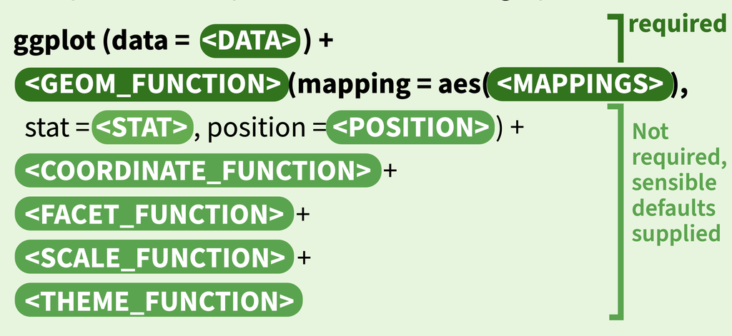

`ggplot2` is built on layers. The sequence of layers matter – it is best to follow the guide above.

We first call `ggplot()` to supply the data and aesthetics. Aesthetics is where we supply the x and y variables.

```r
mtcars %>%
  ggplot(mapping = aes(x = hp, y = mpg))
```

Next, we add geom functions. A few will be used particularly often.

Single variable

- `geom_density`: smoothed density plot (single-variable only)
- `geom_histogram`: histogram (single-variable only)

Two variables

- `geom_point`: scatter plot
- `geom_text`: used to add text to visualizations
- `geom_smooth`: smoothed conditional means
- `geom_errorbar`: error bars

We can add geoms on top of each other.

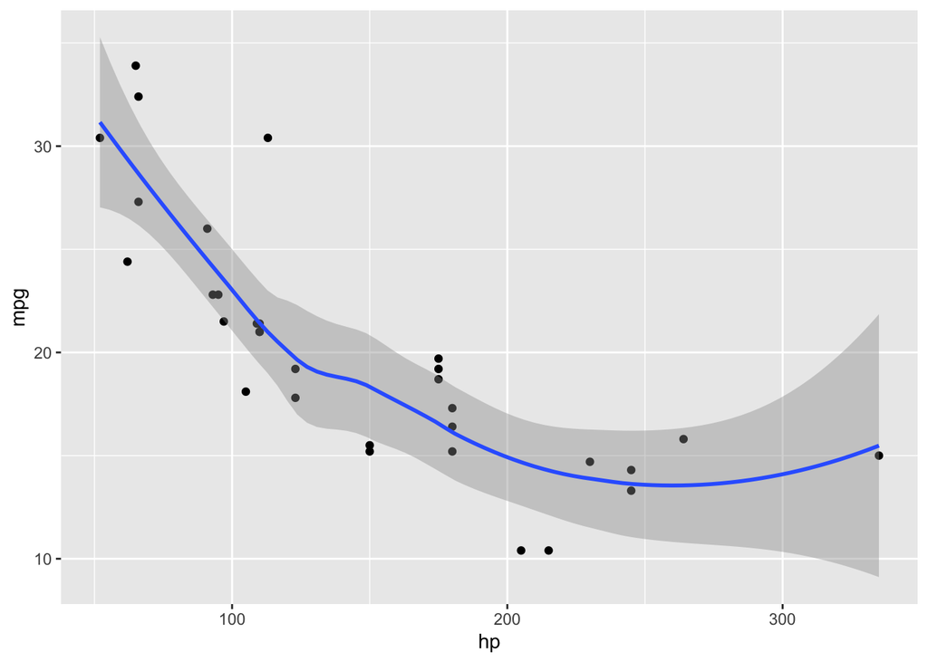

```r
mtcars %>%
  ggplot(mapping = aes(x = hp, y = mpg)) +
  geom_point() +
  geom_smooth()
```

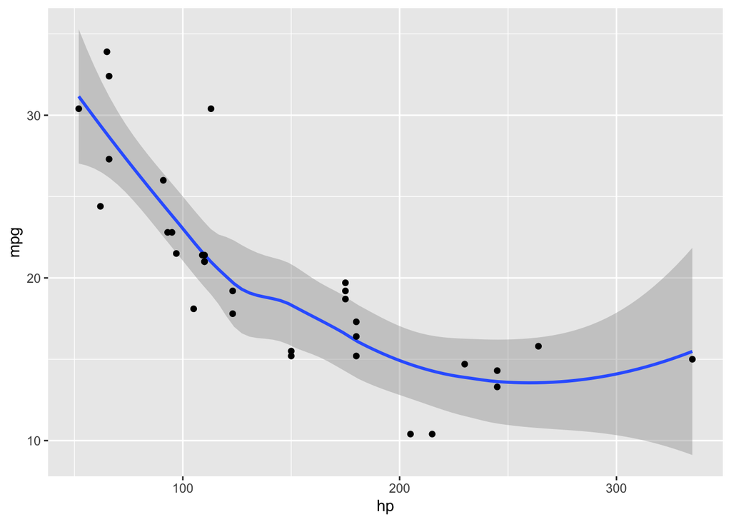

```r
mtcars %>%
  ggplot(mapping = aes(x = hp, y = mpg)) +
  geom_smooth() +
  geom_point()
```

The sequence of geoms matters! Do you see the difference?

It is helpful to check the help files to see which aesthetics can be used for each geom function. For example, `color` is often used to indicate covariates. Besides, we can change the size of the points using `size` and the line type using `linetype`.

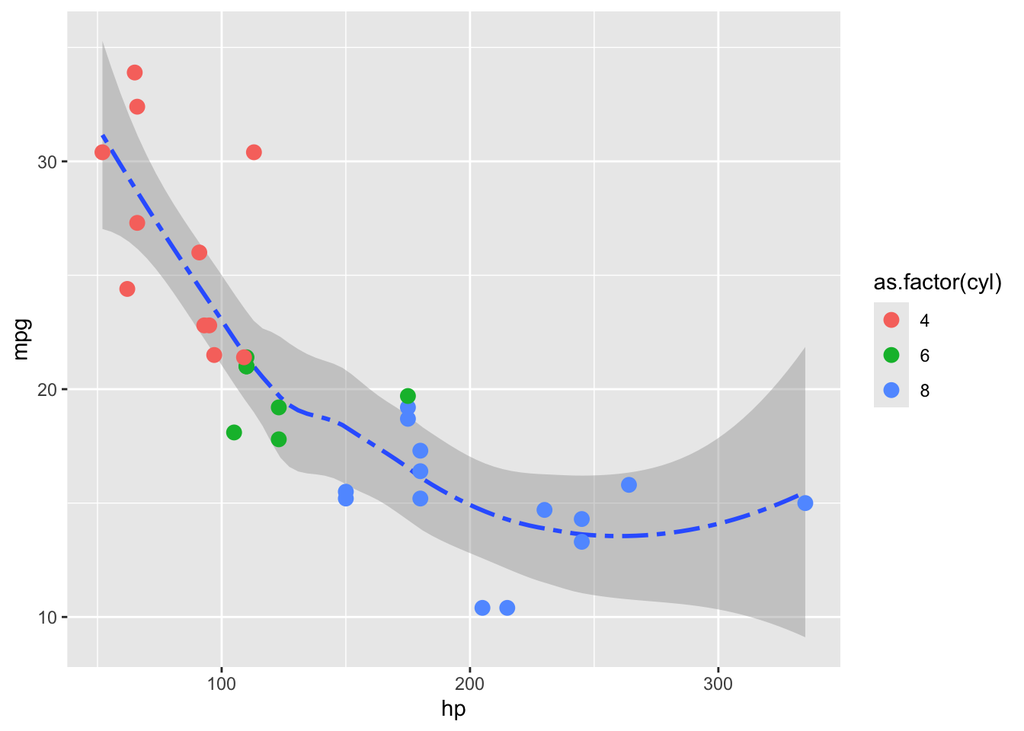

```r
mtcars %>%
  ggplot(mapping = aes(x = hp, y = mpg)) +
  geom_smooth(linetype = 6) +
  geom_point(aes(color = as.factor(cyl)), size = 3)
```

**Debugging exercise**

Say I wanted to make the previous graph and ran the following code:

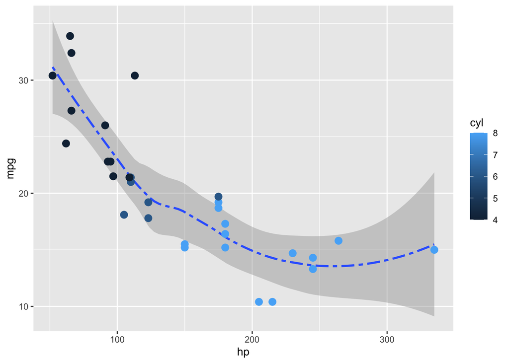

```r
mtcars %>%
  ggplot(mapping = aes(x = hp, y = mpg)) +
  geom_smooth(linetype = 6) +
  geom_point(aes(color = cyl), size = 3)
```

The colors of the points were not what I had intended them to be. How would you go about identifying the source of the issue and deploying a fix?

Customizing aesthetics can make a huge difference in presentation. Consider the following histograms:

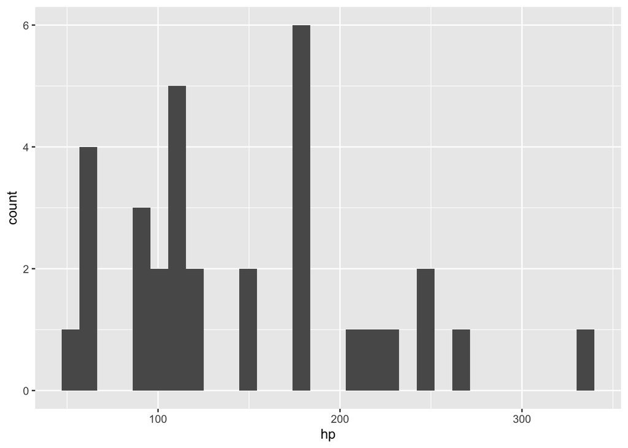

```r
mtcars %>%
  ggplot(mapping = aes(x = hp)) +
  geom_histogram()
```

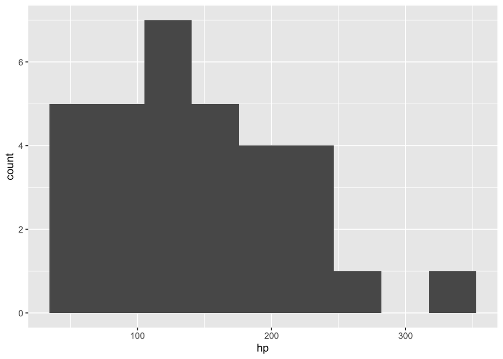

```r
mtcars %>%
  ggplot(mapping = aes(x = hp)) +
  geom_histogram(bins = 9)
```

After geoms, we can use scale functions (typically `scale_x_continuous`, `scale_x_discrete`, `scale_y_continuous`, or `scale_y_discrete`) to modify the scales on the axes. This can include customizing the labels of the scales, the limits of the axes, the number of breaks, etc.

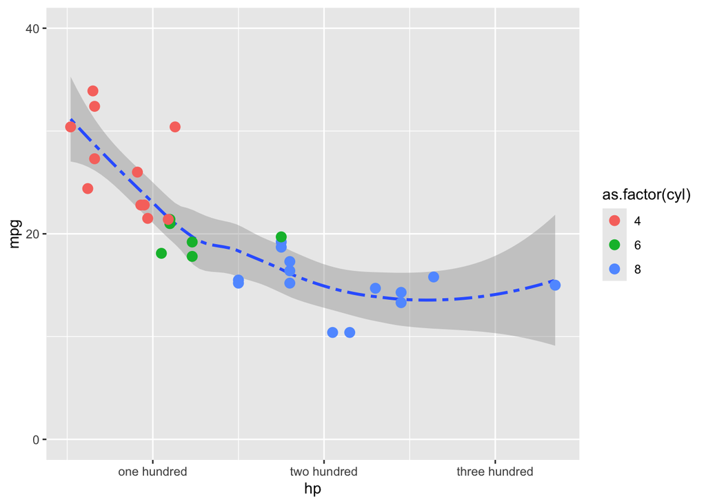

```r
mtcars %>%
  ggplot(mapping = aes(x = hp, y = mpg)) +
  geom_smooth(linetype = 6) +
  geom_point(aes(color = as.factor(cyl)), size = 3) +
  scale_x_continuous(breaks = c(100, 200, 300),
                     labels = c("one hundred", "two hundred", "three hundred")) +
  scale_y_continuous(limits = c(0, 40), n.breaks = 3)
```

Customize your visualization by customizing the `theme()`, or using a preset such as `theme_bw()`.

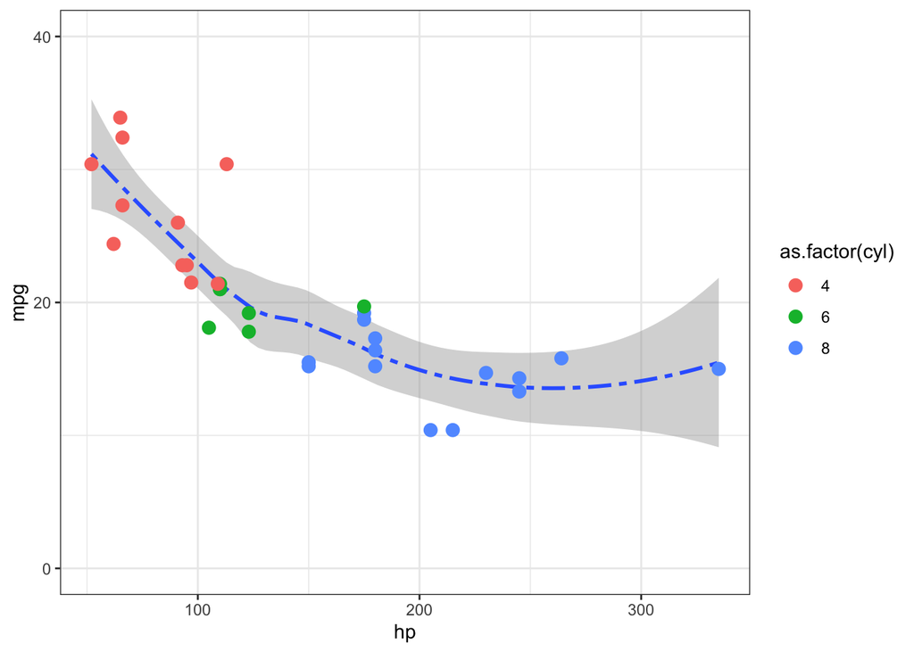

```r
mtcars %>%
  ggplot(mapping = aes(x = hp, y = mpg)) +
  geom_smooth(linetype = 6) +
  geom_point(aes(color = as.factor(cyl)), size = 3) +
  scale_x_continuous(breaks = c(100, 200, 300)) +
  scale_y_continuous(limits = c(0, 40), n.breaks = 3) +
  theme_bw()
```

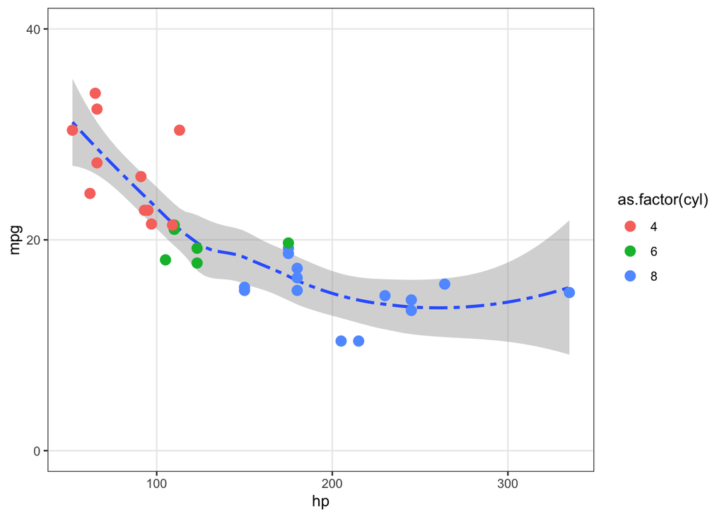

```r
mtcars %>%
  ggplot(mapping = aes(x = hp, y = mpg)) +
  geom_smooth(linetype = 6) +
  geom_point(aes(color = as.factor(cyl)), size = 3) +
  scale_x_continuous(breaks = c(100, 200, 300)) +
  scale_y_continuous(limits = c(0, 40), n.breaks = 3) +
  theme_bw() +
  theme(panel.grid.minor = element_blank())
```

Sometimes, you may want to divide a plot into subplots based on a discrete variable/covariate. This can be achieved using facets, and we can use multiple variables for this.

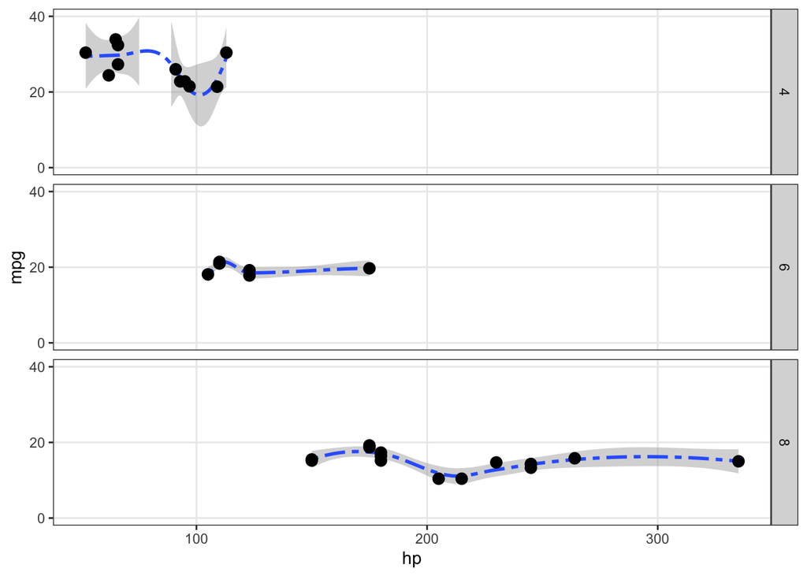

```r
mtcars %>%
  ggplot(mapping = aes(x = hp, y = mpg)) +
  geom_smooth(linetype = 6) +
  geom_point(size = 3) +
  facet_grid(vars(cyl)) +
  scale_x_continuous(breaks = c(100, 200, 300)) +
  scale_y_continuous(limits = c(0, 40), n.breaks = 3) +
  theme_bw() +
  theme(panel.grid.minor = element_blank())
```

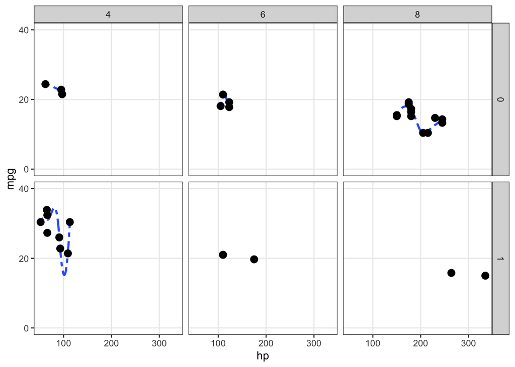

```r
mtcars %>%
  ggplot(mapping = aes(x = hp, y = mpg)) +
  geom_smooth(linetype = 6, se = FALSE) +
  geom_point(size = 3) +
  facet_grid(am ~ cyl) +
  scale_x_continuous(breaks = c(100, 200, 300)) +
  scale_y_continuous(limits = c(0, 40), n.breaks = 3) +
  theme_bw() +
  theme(panel.grid.minor = element_blank())
```

Finally, do not forget to customize labels for the visualization to be legible!

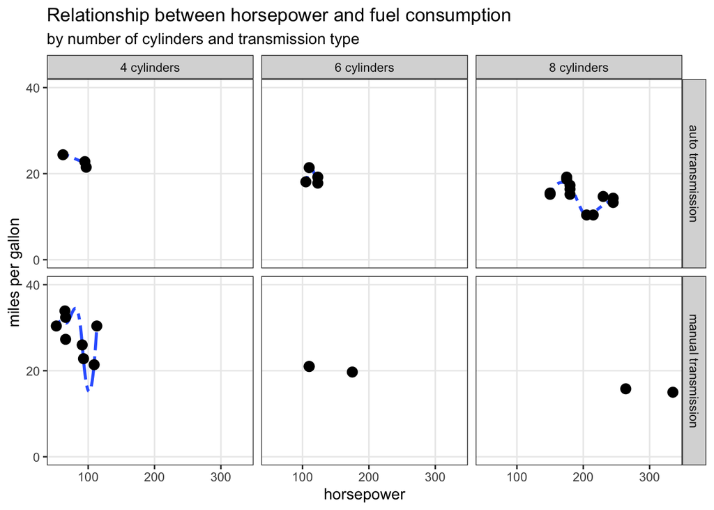

```r
mtcars %>%
  ggplot(mapping = aes(x = hp, y = mpg)) +
  geom_smooth(linetype = 6, se = FALSE) +
  geom_point(size = 3) +
  facet_grid(
    am ~ cyl,
    labeller = labeller(
      am = c(`0` = "auto transmission", `1` = "manual transmission"),
      cyl = c(`4` = "4 cylinders", `6` = "6 cylinders", `8` = "8 cylinders")
    )
  ) +
  scale_x_continuous(breaks = c(100, 200, 300)) +
  scale_y_continuous(limits = c(0, 40), n.breaks = 3) +
  theme_bw() +
  theme(panel.grid.minor = element_blank(),
        legend.position = "none") +
  labs(x = "horsepower", y = "miles per gallon",
       title = "Relationship between horsepower and fuel consumption",
       subtitle = "by number of cylinders and transmission type")
```